# PSSDplusplus walkthrough

# Overview

This document provides a minimal, end-to-end walkthrough of the **PSSD++ probabilistic ecotoxicological threshold framework** implemented in the `PSSDplusplus` R package. The workflow demonstrates how microplastic (MP) hazard thresholds are derived across environments and Effect–Response Metrics (ERMs) using Monte Carlo uncertainty propagation and probabilistic Species Sensitivity Distributions (pSSDs).

The analytical pipeline mirrors that described in **Coffin et al. (2026)** and related manuscripts, while remaining compact enough for method development, debugging, and demonstration.

## Overview of the PSSD++ Framework

The PSSD++ framework integrates the following components:

- **Monte Carlo (MC) uncertainty propagation**
- **Probabilistic Species Sensitivity Distributions (pSSDs)**
- **Alignment of laboratory toxicity data to environmentally relevant MP particle distributions**
- **Parallel computation with deterministic caching**

The workflow proceeds through four main stages:

1. Preparation and filtering of toxicity inputs
2. Sampling of alignment and uncertainty parameters
3. Monte Carlo alignment of toxicity data
4. Fitting and summarization of PSSD++ models

## 1) Prepare inputs

By default, the package uses a preprocessed **ToMEx 2.0–derived ecotoxicity dataset**, distributed with the package.

```r
# load in toxicity data (ToMEx 2.0 is default, and is supplied with package)
tox_data <- tomex2
head(tox_data) # view the first few rows of the toxicity data
```

```
#> # A tibble: 6 × 177
#>   rowid       source doi   article fed   tech.a1 tech.a2 tech.a3 tech.a4 tech.a5
#>   <chr>       <fct>  <chr>   <dbl> <fct>   <dbl>   <dbl>   <dbl>   <dbl>   <dbl>
#> 1 84a8cb7b-2… Koelm… 10.7…       1 Yes         2       2       2       2       2
#> 2 ae6b0751-8… Koelm… 10.7…       1 Yes         2       2       2       2       2
#> 3 da42217a-6… Koelm… 10.7…       1 Yes         2       2       2       2       2
#> 4 dd0d9f76-e… Koelm… 10.7…       1 Yes         2       2       2       2       2
#> 5 5f1923b7-9… Koelm… 10.7…       1 Yes         2       2       2       2       2
#> 6 b247eea7-d… Koelm… 10.7…       1 Yes         2       2       2       2       2
#> # ℹ 167 more variables: tech.a6 <dbl>, tech.1 <dbl>, tech.2 <dbl>,
#> #   tech.3 <dbl>, tech.4 <dbl>, tech.5 <dbl>, tech.6 <dbl>, tech.7 <dbl>,
#> #   tech.8 <dbl>, tech.9 <dbl>, tech.10 <dbl>, tech.11 <dbl>, tech.12 <dbl>,
#> #   risk.b1 <dbl>, risk.13 <dbl>, risk.14 <dbl>, risk.15 <dbl>, risk.16 <dbl>,
#> #   risk.17 <dbl>, risk.18 <dbl>, risk.19 <dbl>, risk.20 <dbl>,
#> #   technical.quality <dbl>, risk.quality <dbl>, authors <chr>, year <dbl>,
#> #   Species <fct>, Group <fct>, env_f <fct>, life_f <fct>, vivo_f <fct>, …
```

The user may choose to filter the toxicity data based on specific criteria (e.g., species, exposure duration, endpoints, quality criteria, etc.). Each of these criteria can be applied using the `filter()` function from the `dplyr` package. Filtering options applied in Mehinto et al. (2022) are applied below:

```r
tox_data <- tox_data |>
  dplyr::filter(
    Group != "Bacterium", # Drop studies with Bacterium group
    Group != "Plant", # Drop studies with Plant group
    effect.metric != "HONEC", # Drop studies with HONEC effect metric
    tier_zero_tech_f == "Red Criteria Passed", #minimum QC for technical criteria
    tier_zero_risk_f == "Red Criteria Passed", #minimum QC for risk criteria
    risk.13 != 0 #Drop studies that received a score of 0 for endpoints criteria (this also drops studies that have not yet been)
  )
```

## 2) Sample alignment parameters

Use the defaults from the manuscript (i.e., Kooi et al. 2021)[https://doi.org/10.1016/j.envpol.2021.117898] or pass a custom `params` table. Note that the parameter names cannot change - regardless of what the user’s specified environment is. For instance, if the user would like to model a brackish water environment, simply update the parameters for either ‘marine’ or ‘freshwater’ with the brackish parameters, while keeping the original names of parameters intact.

```r
param_default_values <- PSSDplusplus::param_default_values
#view parameters
head(param_default_values)
```

```
#>   R.ave.water.marine R.ave.water.marine.sd R.ave.water.freshwater
#> 1               0.77                  0.29                   0.67
#>   R.ave.water.freshwater.sd R.ave.sediment.marine R.ave.sediment.marine.sd
#> 1                      0.28                  0.75                      0.3
#>   R.ave.sediment.freshwater R.ave.sediment.freshwater.sd p.ave.marine
#> 1                       0.7                         0.33          1.1
#>   p.ave.marine.sd p.ave.freshwater p.ave.freshwater.sd alpha.marine
#> 1            0.14             1.04                0.12         2.07
#>   alpha.marine.sd a.sa.marine a.sa.marine.sd a.v.marine a.v.marine.sd
#> 1            0.03         1.5          0.009       1.48          0.06
#>   a.m.marine a.m.marine.sd alpha.freshwater alpha.freshwater.sd a.sa.freshwater
#> 1       1.45          0.08             2.25                0.19            1.55
#>   a.sa.freshwater.sd a.v.freshwater a.v.freshwater.sd a.m.freshwater
#> 1              0.028           1.68             0.081           1.65
#>   a.m.freshwater.sd a.ssa.freshwater a.ssa.freshwater.sd beta_log10_body_length
#> 1             0.071             2.71               0.009                 0.9341
#>   se_beta_log10_body_length body_length_intercept se_body_length_intercept
#> 1                    0.1376                  1.12                   0.3222
#>     beta_0 se_beta_0      beta_1   se_beta_1
#> 1 1.308344 0.3963612 -0.01468148 0.006657993
```

A parameter distribution dataset may be simulated using each respective parameters’ distributions (e.g., alpha power law, normal distributions, etc.). By default, the package uses a Latin Hypercube Sampling approach to generate the parameter matrix. If the user wants to user alternative distributions for each parameter, the matrix_function() should be modified accordingly. Note that only water parameters are used in this version of the package, with future versions potentially including sediment.

```r
param_matrix <- matrix_function(
  n = 5, #size of matrix (10,000 is recommended)
  params = param_default_values, #parameter distribution values -replace with user's specifications
  upper.tissue.truncation.limit = 500, # maximum particle size (microns) to truncate tissue tranlocation size limit distribution to based on biological plausibility
  x1M_set = 1, #minimum particle size to generate distributions to in microns
  x2D_set = 5000 #maximum particle size to generate distributions to in microns
)
```

Visualize the sampled draws (each element is a ggplot object):

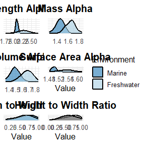

```r
param_plots <- parameter_histograms_function(param_matrix) # generate parameter distribution plots
#visualize plots
param_plots$alpha_combined_plot # distribution of alpha parameters
```

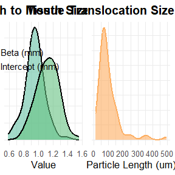

```r
param_plots$tissue_body #distribution of tissue translocation and mouth size opening model parameters
```

## 3) Run Monte Carlo alignments

The following code aligns the toxicity data to the parameter matrix using Monte Carlo simulations.

```r
message("Starting MC_sim_align_parallel...")
```

```
#> Starting MC_sim_align_parallel...
```

```r
MC_sim_df <- MC_sim_align_parallel(
  tox_data = tox_data, # toxicity data (ToMEx 2.0 is default)
  param_matrix = param_matrix, # parameter matrix generated in prior cell
  n_sim = 5, # size of parameter matrix (ensure this is the same as the size of the matrix generated)
  x1D_set = 1, # minimum particle size to generate distributions to (in microns)
  x2D_set = 5000, # maximum particle size to generate distributions to (in microns)
  num_cores = num_cores # number of cores to use for parallel processing (specify )
)
```

```
#> Using 1 cores for parallel processing
#>   |                                                                              |                                                                      |   0%Running alignments for 5 simulation(s)  |                                                                              |==============     …
#> Probabilistic alignments completed in 2.5 sec
```

```r
message("Finished MC_sim_align_parallel.")
```

```
#> Finished MC_sim_align_parallel.
```

### Split the aligned data into ERM- and environment-specific subsets

Split the aligned data into ERM- and environment-specific registries to replicate the results from Coffin et al. (2026).

```r
results_df_food <- dplyr::filter(
  MC_sim_df,
  ingestible != "not ingestible",
  particles_L_food_dilution > 0,
  Group != "Algae"
) |>
  dplyr::mutate(dose_new_particles_L = particles_L_food_dilution) |>
  tidyr::drop_na(particles_L_food_dilution)
results_df_food_t3_t4 <- dplyr::filter(
  results_df_food,
  risk.13 != 1,
  bio_f %in% c("Organism", "Population")
)

results_df_tissue <- dplyr::filter(
  MC_sim_df,
  translocatable != "not translocatable",
  particles_L_ox_stress > 0
) |>
  dplyr::mutate(dose_new_particles_L = particles_L_ox_stress) |>
  tidyr::drop_na(particles_L_ox_stress)
results_df_tissue_t3_t4 <- dplyr::filter(
  results_df_tissue,
  risk.13 != 1,
  bio_f %in% c("Organism", "Population")
)

erm_registry <- list(
  "Food Dilution" = list(base = results_df_food, t3_t4 = results_df_food_t3_t4),
  "Tissue Translocation" = list(base = results_df_tissue, t3_t4 = results_df_tissue_t3_t4)
)
```

## 4) Fit PSSD++s

The following code performs the fitting of PSSD++ models to the aligned data:

```r
message("Starting make_all_pSSDs...")
```

```
#> Starting make_all_pSSDs...
```

```r
# call object for usage by rtrunc later (this ONLY needs to be done in the vignette, which cannot load other libraries in the file)
rtrapezoid <- trapezoid::rtrapezoid
ptrapezoid <- trapezoid::ptrapezoid
qtrapezoid <- trapezoid::qtrapezoid
dtrapezoid <- trapezoid::dtrapezoid

# make all pSSDs
pSSDs <- make_all_pSSDs(
  MC_sim_df = MC_sim_df, # ensure aligned data is included
  environments = c("Freshwater", "Marine"), #specify which environments to include
  erm_registry = erm_registry,
  sim = 5, # specify the number of simulations to run
  cv_uf = 0.5, # specify the coefficient of variation for uncertainty factors (acute -> chronic and LOEC/EC50 -> NOEC)
  rmore_method = "step", # method to handle pSSD distribution building (options = 'step' i.e., original trapezoidal method in Wigger et al., 2020, or 'lognormal' - shortcut developed in Coffin et al. (2025))
  quantile_type = 8, # quantile type for distribution fitting (8 is default, and use of others may cause unexpected or unreliable results)
  parallel = parallel_enabled, #whether or not to use parallel processing
  workers = workers, # number of worker processes to use for parallel processing
  base_cache_dir = file.path(tempdir(), "pssd_cache"), # directory to store cached pSSD objects (important when running high number of simulations to resume if needed)
  base_output_path = file.path(tempdir(), "pssd_figures"), # directory to store output figures
  overwrite_cache = TRUE # whether or not to overwrite cached pSSD objects
)
```

```
#> ⚙️ Running PSSD combinations sequentially
#> 🚀 Starting PSSD analysis with 5 sims each...
#> ⏳ 20% complete (1 of 5 simulations done)
#> ⏳ 40% complete (2 of 5 simulations done)
#> ⏳ 60% complete (3 of 5 simulations done)
#> ⏳ 100% complete (5 of 5 simulations done)
#> ✅ PSSD analysis for tier3_Food Dilution complete and saved.
#> ✅ Completed: Tier3_Freshwater_Food Dilution
#> 🚀 Starting PSSD analysis with 5 sims each...
#> ⏳ 20% complete (1 of 5 simulations done)
#> ⏳ 40% complete (2 of 5 simulations done)
#> ⏳ 60% complete (3 of 5 simulations done)
#> ⏳ 100% complete (5 of 5 simulations done)
#> ✅ PSSD analysis for tier3_Food Dilution complete and saved.
#> ✅ Completed: Tier3_Marine_Food Dilution
#> 🚀 Starting PSSD analysis with 5 sims each...
#> ⏳ 20% complete (1 of 5 simulations done)
#> ⏳ 40% complete (2 of 5 simulations done)
#> ⏳ 60% complete (3 of 5 simulations done)
#> ⏳ 100% complete (5 of 5 simulations done)
#> ✅ PSSD analysis for tier3_Tissue Translocation complete and saved.
#> ✅ Completed: Tier3_Freshwater_Tissue Translocation
#> 🚀 Starting PSSD analysis with 5 sims each...
#> ⏳ 20% complete (1 of 5 simulations done)
#> ⏳ 40% complete (2 of 5 simulations done)
#> ⏳ 60% complete (3 of 5 simulations done)
#> ⏳ 100% complete (5 of 5 simulations done)
#> ✅ PSSD analysis for tier3_Tissue Translocation complete and saved.
#> ✅ Completed: Tier3_Marine_Tissue Translocation
```

```r
message("Finished make_all_pSSDs.")
```

```
#> Finished make_all_pSSDs.
```

### Examine pSSD++ output

Each ERM x Environment combination is saved as a list element, with corresponding PNEC quantiles, summary statistics, and plots.

#### PNEC Summary

```r
PNEC_summary <- summarize_PNECs(pSSDs)
head(PNEC_summary)
```

[output not shown]

PNEC distributions are visualized using ggplot:

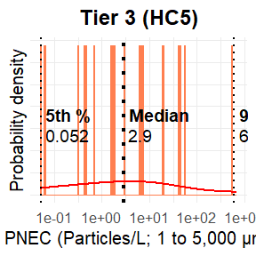

```r
pSSDs$`Tier3_Freshwater_Food Dilution`$PNEC_plot_05
```

#### pSSD++ Plots

The pSSD++ plots show the relationship between the exposure concentration and the predicted effect levels.

[figure not shown]

```r
# view pSSD plot for example:
pSSDs$`Tier3_Freshwater_Food Dilution`$pSSD_plot
```

#### Arranged plot

[figure not shown]

```r
pSSDs$`Tier3_Freshwater_Food Dilution`$arranged_plot
```

The cache and figure outputs default to temporary directories; override the paths above to persist artifacts between sessions.